# NFHS-5

Exploration of District-Level Data

We use data from the NFHS-5 state and district fact sheets to do an exploratory data analysis. The data release was limited to 22 states and UTs. See the last section of this document for the data sources used.

# 1 Malnutrition among Children

In this section, we look at the stunting, wasting, underweight and overweight indicators among children under the age of 5 years. Here are the indicators used:

- **Stunting**: Children under 5 years with a **height-for-age** ratio 2 standard deviations lower than the WHO standard average.
- **Wasting**: Children under 5 years with a **weight-for-height** ratio 2 standard deviations lower than the WHO standard average.
- **Severe Wasting**: Children under 5 years with a **weight-for-height** ratio 3 standard deviations lower than the WHO standard average.
- **Underweight**: Children under 5 years with a **weight-for-age** ratio 2 standard deviations lower than the WHO standard average.
- **Overweight**: Children under 5 years with a **weight-for-height** ratio 2 standard deviations higher than the WHO standard average.

## 1.1 India: State-Level Picture

The 22 states and UTs for which the reports were released are included in the plots.

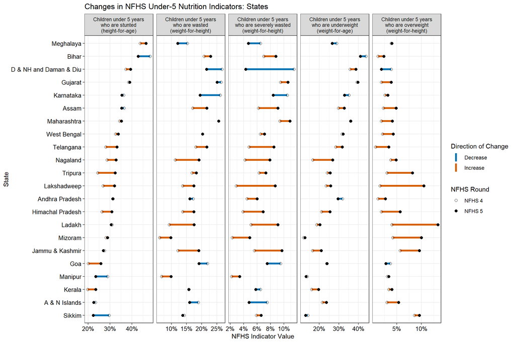

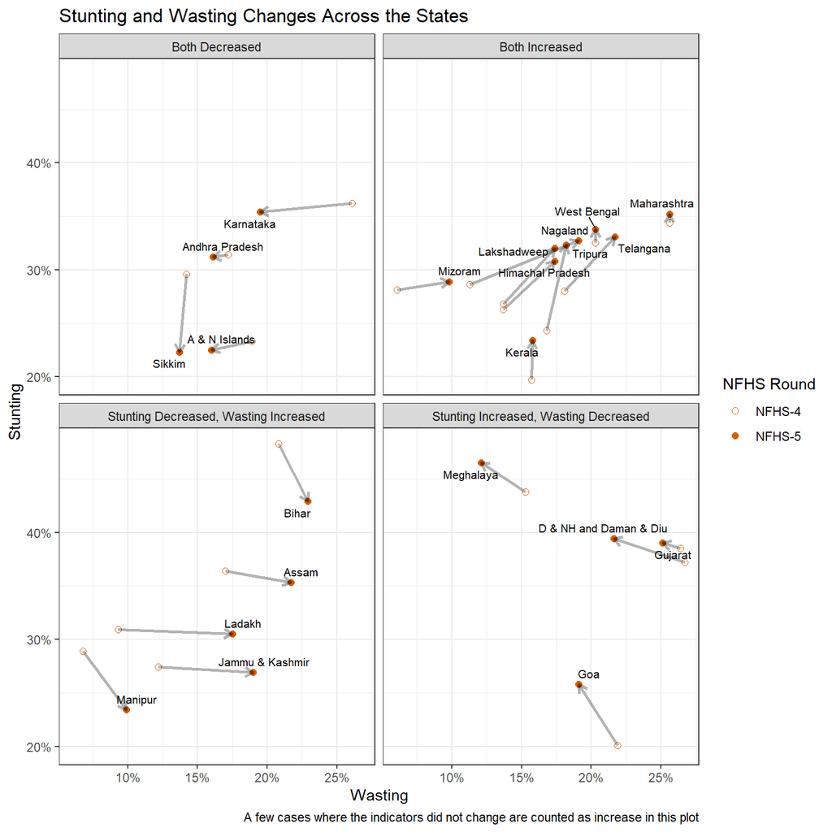

## 1.2 India: Districts

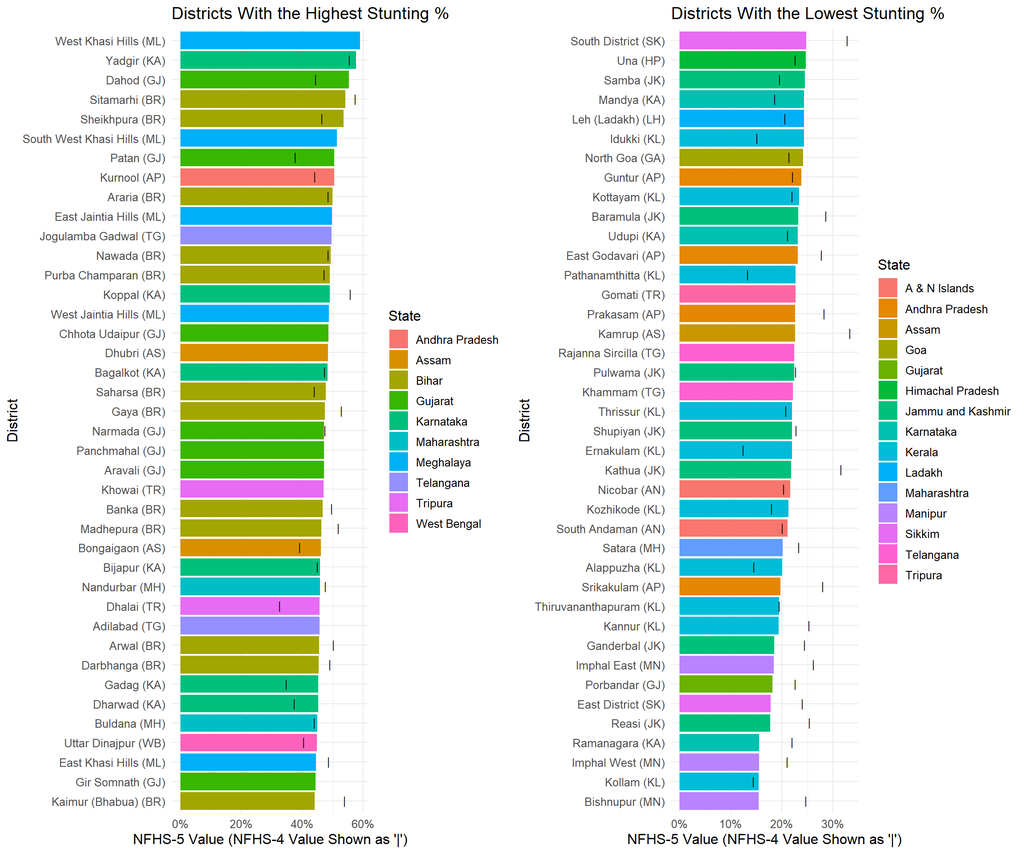

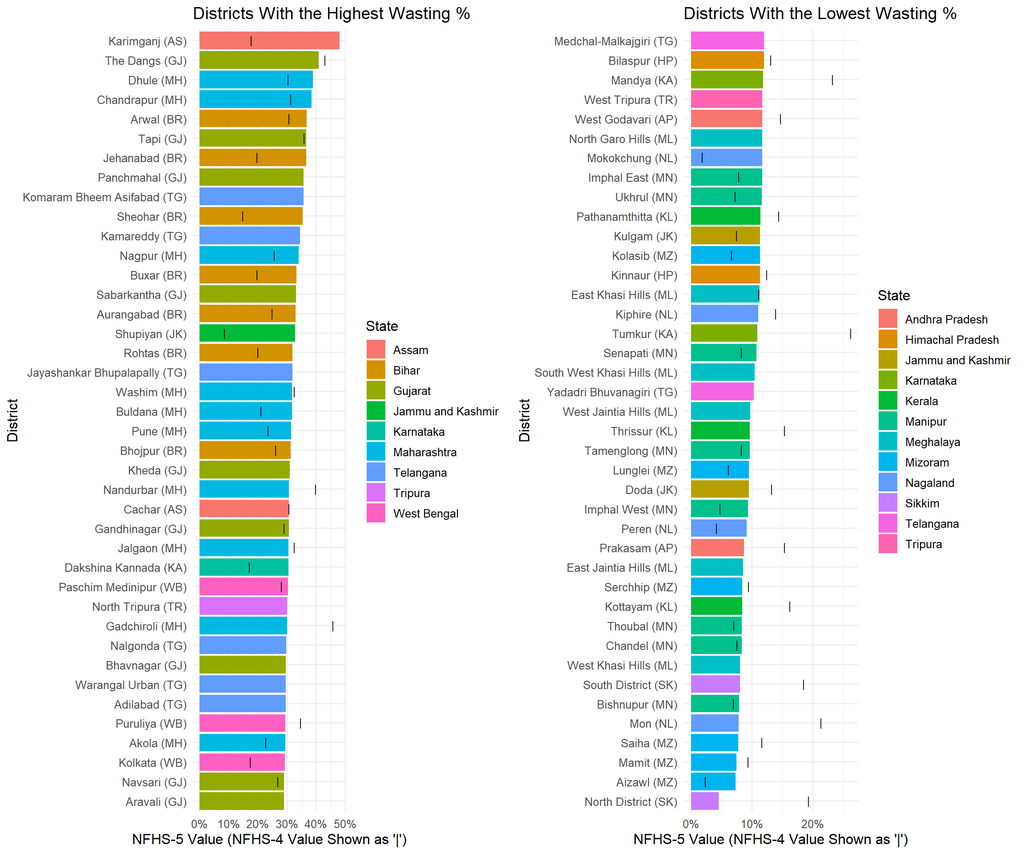

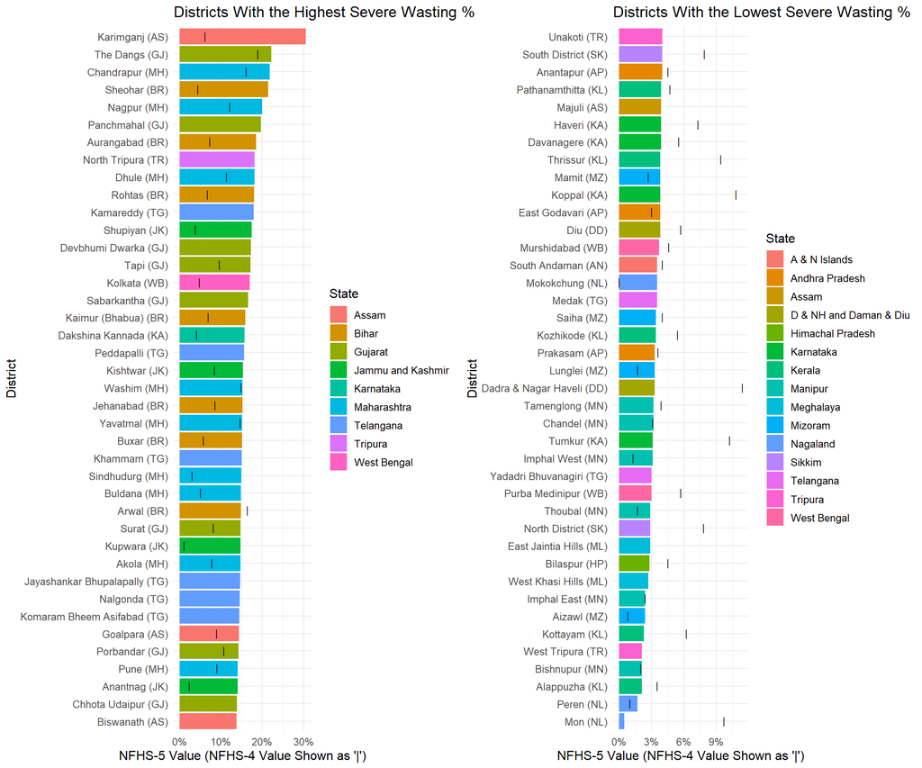

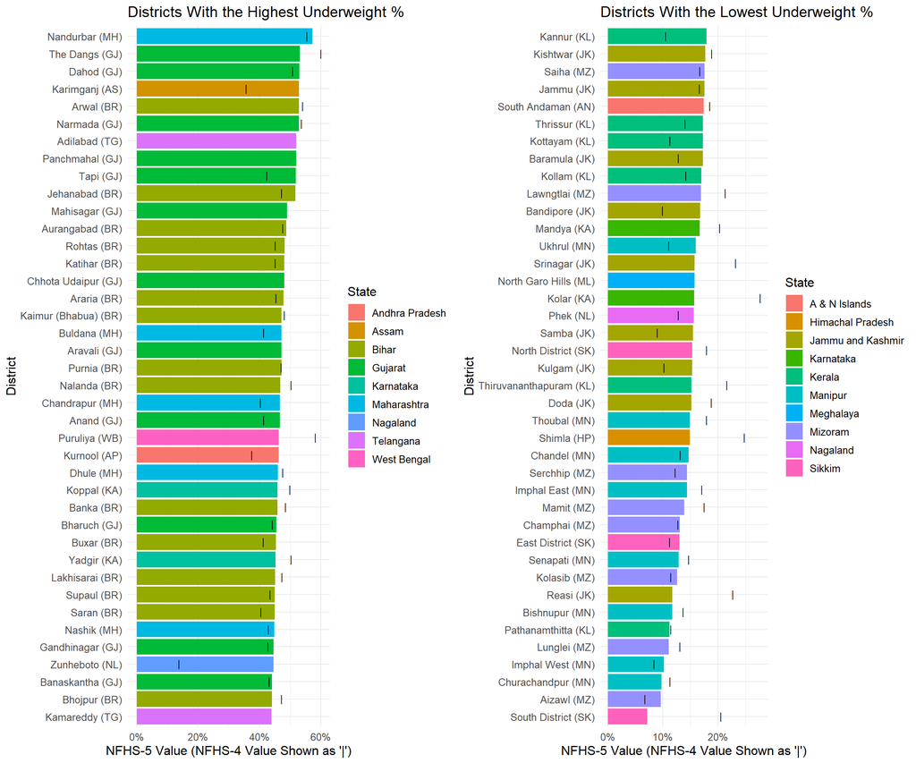

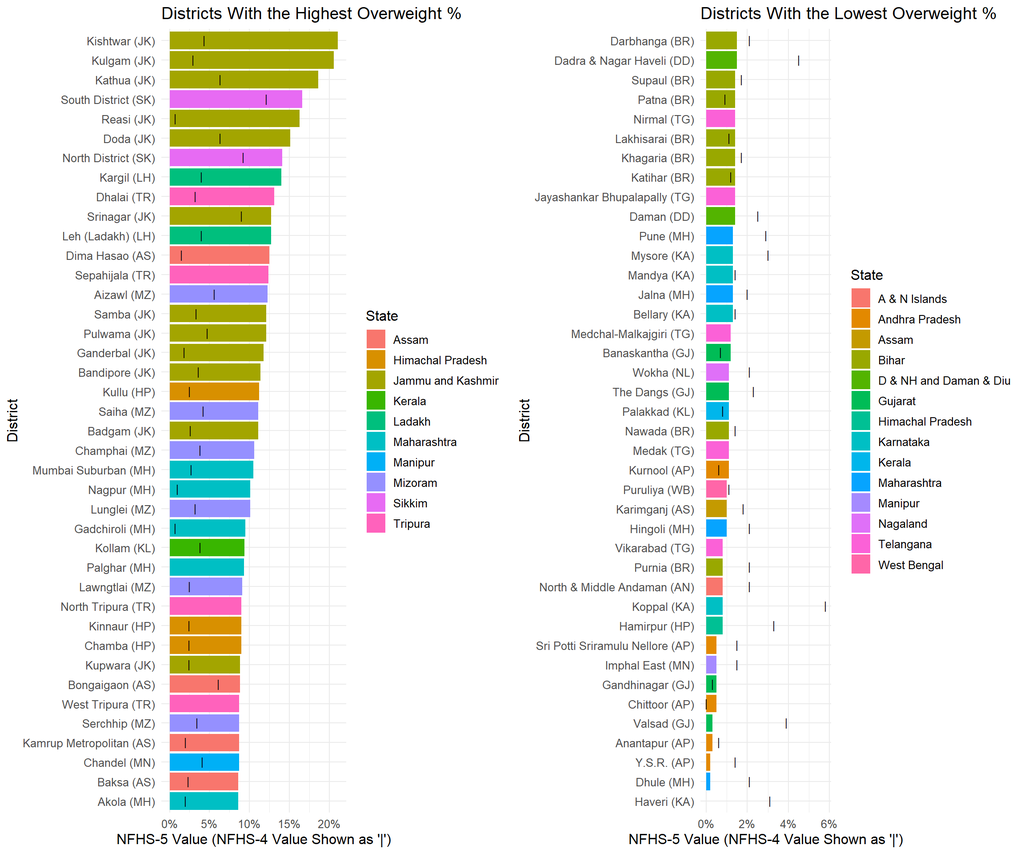

## 1.3 Karnataka

### 1.3.1 Changes Over Time

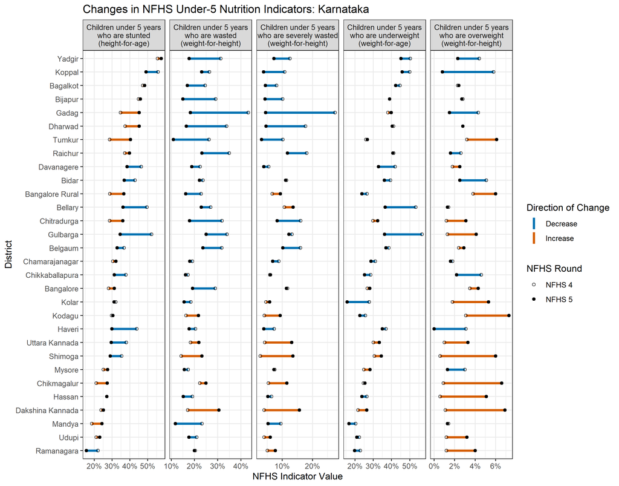

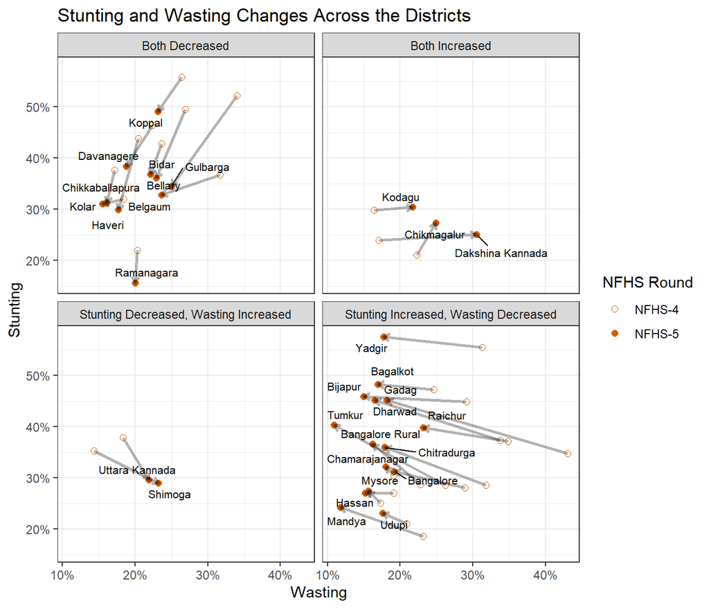

### 1.3.2 Spatial Patterns

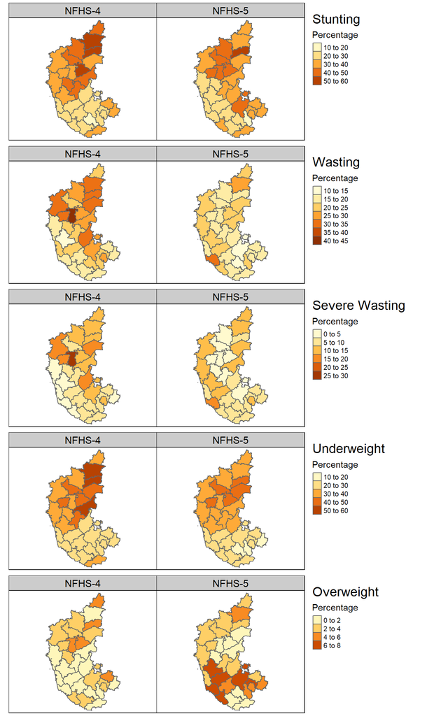

### 1.3.3 Observations

We can see a few patterns:

1. **Mandya, Chikmagalur, Chitradurga, Bangalore Rural, Tumkur, Dharwad, Gadag** - These districts had a significant increase in stunting compared to the last round. Most of these districts, however, had a drop in the wasting indicators.
2. Wasting a severe wasting has improved in the majority of the districts in Karnataka. **Gadag, Dharwad, Tumkur, Raichur, Yadgir, Bijapur, Chitradurga, Mandya, Bangalore** - all of these had a large decline in wasting.
3. Quite surprisingly, a few districts that have a relatively low stunting level has shown major increases in wasting. This pattern can be seen clearly in the districts **Dakshina Kannada, Uttara Kannada, Kodagu, Shimoga and Chikmagalur**. As wasting is known to be caused by shorter term shocks compared to stunting, there is a possibility that some recent changes in the economic or public health situation affected the child nutrition situation across these southern states.

## Code, Data and Credits

This work is licensed under [CC BY 4.0](https://creativecommons.org/licenses/by/4.0/). Copyright: Sooraj Raveendran, Divya Ravindranath, Viola Lewis, Divij Sinja, and Herry Gulabani. 2021 (Indian Institute for Human Settlements)

- This report was prepared in R markdown. The source code and the data is available at https://github.com/soorajmr/nfhs-5-districts. This code is under MIT licence.
- NFHS data extracted from the state and district fact sheets were downloaded from https://github.com/pratapvardhan/NFHS-5, by Pratap Vardhan and Bhanu K.
- The spatial boundaries vector data were taken from https://github.com/datameet/maps, by [DataMeet India community](http://datameet.org/) ([CC BY 4.0](https://creativecommons.org/licenses/by/4.0/)).

Report generated at: 21 May, 2021 02:16 PM